# 5 Ocean Topics

# Sentinel-2A

Satelit **Sentinel-2A** memiliki instrumen multispektral bernama **MultiSpectral Instrument (MSI)** yang merekam bumi dalam **13 saluran (band) spektral**. Rentang panjang gelombangnya mencakup cahaya tampak (Visible), inframerah dekat (Near-Infrared/NIR), hingga inframerah gelombang pendek (Short-Wave Infrared/SWIR).

Setiap band dirancang secara spesifik dengan lebar spektrum (bandwidth) dan resolusi spasial yang bervariasi sesuai fungsinya. Berikut adalah detail karakteristik resolusi spektral dari Sentinel-2A menurut pusat data [NASA Earthdata](https://www.earthdata.nasa.gov/data/instruments/sentinel-2-msi):

| Nomor Band | Nama Saluran Spektral | Panjang Gelombang Tengah (nm) | Lebar Spektrum / Bandwidth (nm) | Resolusi Spasial (m) |
| --- | --- | --- | --- | --- |
| **B01** | Coastal aerosol (Pesisir/Aerosol) | 442.7 | 20 | 60 |
| **B02** | Blue (Biru) | 492.7 | 65 | 10 |
| **B03** | Green (Hijau) | 559.8 | 35 | 10 |
| **B04** | Red (Merah) | 664.6 | 30 | 10 |
| **B05** | Vegetation Red Edge | 704.1 | 14 | 20 |
| **B06** | Vegetation Red Edge | 740.5 | 14 | 20 |
| **B07** | Vegetation Red Edge | 782.8 | 19 | 20 |
| **B08** | NIR (Inframerah Dekat - Lebar) | 832.8 | 105 | 10 |
| **B8A** | Narrow NIR (Inframerah Dekat - Sempit) | 864.7 | 21 | 20 |
| **B09** | Water vapour (Uap Air) | 945.1 | 19 | 60 |
| **B10** | SWIR - Cirrus (Awan Sirus) | 1373.5 | 29 | 60 |
| **B11** | SWIR-1 (Inframerah Gelombang Pendek) | 1613.7 | 90 | 20 |
| **B12** | SWIR-2 (Inframerah Gelombang Pendek) | 2202.4 | 174 | 20 |

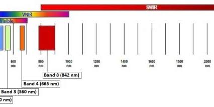

image

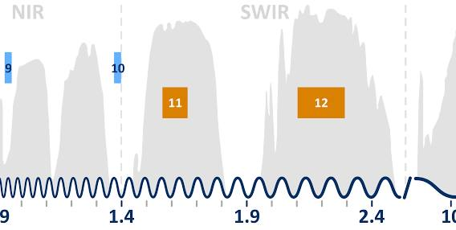

image

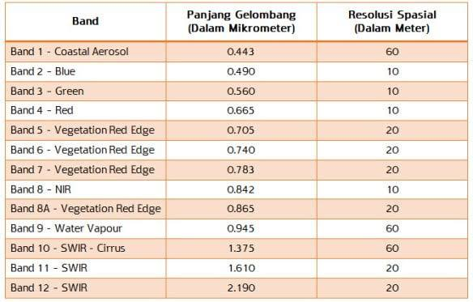

image

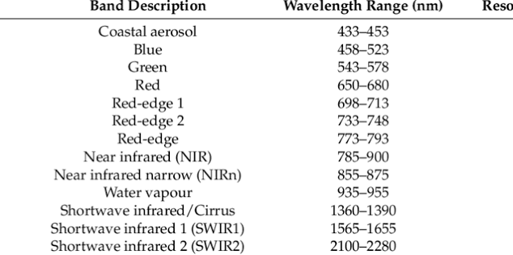

image

Keunggulan Utama Spektral Sentinel-2A

- **Kombinasi *Red Edge* (B5, B6, B7)**: Saluran khusus ini sangat sensitif terhadap perubahan klorofil tanaman. Sangat berguna untuk mendeteksi tingkat kesehatan vegetasi, stres tanaman, maupun klasifikasi jenis hutan.
- **Dua Saluran SWIR (B11 & B12)**: Sangat optimal untuk membedakan kelembapan tanah, kandungan air pada daun, serta memetakan area yang terbakar akibat kebakaran hutan.

Resolusi spektral ditentukan oleh **banyaknya saluran (band)** dan **seberapa sempit saluran tersebut** dalam menangkap gelombang cahaya.

Berikut adalah 3 tingkatan contoh untuk memahaminya:

1. Tingkat Rendah: Citra Pankromatik (1 Saluran Lebar)

- **Contoh**: Foto udara hitam-putih jadul atau sensor Google Earth resolusi tinggi yang hanya menampilkan warna keabuan.
- **Cara Kerja**: Sensor hanya memiliki **1 band yang sangat lebar** yang mencakup seluruh spektrum cahaya tampak (merah, hijau, dan biru digabung jadi satu).
- **Hasil**: Anda hanya bisa melihat bentuk objek (mobil, rumah, pohon) lewat perbedaan terang-gelap (tingkat keabuan), tetapi tidak tahu warna aslinya atau kesehatan tanamannya.

2. Tingkat Menengah: Citra Multispektral (3 hingga belasan Saluran)

- **Contoh**: Kamera HP Anda (3 band: *Red, Green, Blue*) atau satelit **Sentinel-2A** (13 band).
- **Cara Kerja**: Sensor memisahkan cahaya ke dalam kotak-kotak warna yang spesifik. Kamera HP hanya memisahkannya menjadi 3 warna dasar untuk mata manusia. Sementara satelit Sentinel-2 menambahkan kotak ekstra untuk menangkap cahaya yang tidak bisa dilihat manusia, seperti *Near-Infrared* (NIR) dan *Short-Wave Infrared* (SWIR).
- **Hasil (Aplikasi Nyata)**:
  - Jika Anda melihat hutan dengan **Band Merah + Hijau + Biru**, hutan hanya terlihat berwarna hijau biasa.
  - Namun, jika Anda beralih menggunakan **Band Near-Infrared (NIR)**, pohon yang sehat akan memantulkan cahaya NIR dengan sangat kuat dan tampak merah menyala, sementara pohon yang stres/sakit akan tampak redup.

3. Tingkat Tinggi: Citra Hiperspektral (Ratusan Saluran Sempit)

- **Contoh**: Satelit PRISMA (Italia) atau EnMAP (Jerman) yang memiliki **lebih dari 200 band**.
- **Cara Kerja**: Alih-alih membagi warna merah menjadi satu kotak besar, citra hiperspektral membagi warna merah tersebut menjadi puluhan kotak kecil yang sangat detail dan berurutan.
- **Hasil**: Keakuratan warnanya sangat ekstrem. Satelit tidak hanya tahu bahwa objek tersebut adalah “pohon hutan”, tetapi sensor bisa membedakan secara spesifik antara **pohon kelapa sawit, pohon karet, dan pohon jati** hanya dari sidik jari spektral (pantulan warnanya).

Rangkuman Perbandingan

| Karakteristik | Rendah (Pankromatik) | Menengah (Multispektral) | Tinggi (Hiperspektral) |
| --- | --- | --- | --- |
| **Jumlah Band** | 1 Band | 3 – 20 Band | 100 – Ratusan Band |
| **Lebar Saluran** | Sangat Lebar | Sedang | Sangat Sempit & Rapat |
| **Kemampuan** | Melihat bentuk & batas objek | Membedakan air, tanah, & vegetasi | Mengidentifikasi jenis mineral atau spesies pohon secara spesifik |

Cara mengakses data global PRISMA (Italia) dan EnMAP (Jerman) dari kedua satelit tersebut:

(Tinggi (Hiperspektral))

1. PRISMA (Italia)

Satelit milik Badan Antariksa Italia (ASI) ini menyediakan cakupan wilayah global (antara lintang 70°S hingga 70°N).

- **Status Data**: **Gratis dan Terbuka** untuk komunitas riset, akademisi, dan aplikasi komersial setelah menyetujui syarat dan ketentuan.
- **Cara Mengakses**:
  1. Anda wajib membuat akun melalui [Portal Registrasi Pengguna PRISMA ASI](https://prismauserregistration.asi.it/).
  2. Setelah disetujui, Anda dapat mencari, melihat katalog, dan mengunduh data arsip global maupun produk baru lewat portal PRISMA ASI.
- **Format Data**: Didistribusikan dalam format **HDF5 (.he5)**. Anda bisa menggunakan bantuan *plugin* SNAP atau pustaka bahasa pemrograman seperti `rPRISMA` di R untuk mengubahnya menjadi GeoTIFF agar lebih mudah diolah.

2. EnMAP (Jerman)

Satelit hiperspektral milik Pusat Dirgantara Jerman (DLR) ini dirancang untuk memantau ekosistem bumi dalam skala global (kecuali wilayah kutub ekstrem di atas lintang 77°).

- **Status Data**: **Gratis dan Terbuka** (*Open Data & Open Science Policy*) mengikuti prinsip data FAIR (mudah ditemukan, diakses, diintegrasikan, dan digunakan kembali).
- **Cara Mengakses**:
  1. Lakukan registrasi pengguna di situs resmi [EnMAP](https://www.enmap.org/).
  2. Akses arsip data global yang berisi lebih dari 110.000 produk melalui **EOWEB® GeoPortal**. Anda dapat memilih tingkat pemrosesan data (Level 1B, Level 1C, hingga Level 2A yang sudah terkoreksi atmosfer) secara gratis.
  3. Untuk pengguna ilmiah, Anda bahkan bisa mengajukan usulan perekaman wilayah baru (*tasking/proposals*) melalui *Instrument Planning Portal* mereka jika area yang Anda cari belum ada di arsip.
- **Format Data**: Didistribusikan dalam format **GeoTIFF** standar yang dibungkus dalam arsip terkompresi (.tar.gz), sehingga jauh lebih ramah pengguna untuk langsung dibuka di QGIS atau ArcGIS. DLR juga menyediakan perangkat lunak pengolahan gratis bernama **EnMAP-Box**.

[1]

Fedorov, D. V., “[Interpolation](https://phys.au.dk/~fedorov/Numeric/15/Book/interpolation.pdf),” Course notes, Department of Physics and Astronomy, Aarhus University, 2015.